# allcontributors

Mark Padgham

2024-10-23

The main functionality of the [`allcontributors` package](https://github.com/ropensci/allcontributors) is described in the main [`README`](https://docs.ropensci.org/allcontributors/). This vignette provides a visual reference for the various options available for formatting contributors.

## Default Grid Format

The following represents the default format of contributors divided into three sections (“Code”, “Issue Authors”, and “Issue Contributors”), with each section formatted as a grid with seven columns (determined by the [`ncols` parameter](https://docs.ropensci.org/allcontributors/reference/add_contributors.html)). The images (“Avatars”) are hyperlinked to the main github pages of each contributor, and the github names below them are linked to the contributions made to the package by each contributor. The following uses dummy avatars simply to reduce the compiled size of this vignette, and also uses dummy names for all except the first. (The names are dummy only in the sense of being entirely generic, although they actually do belong to real people - click to find out.)

### Code

[figure not shown]

mpadge

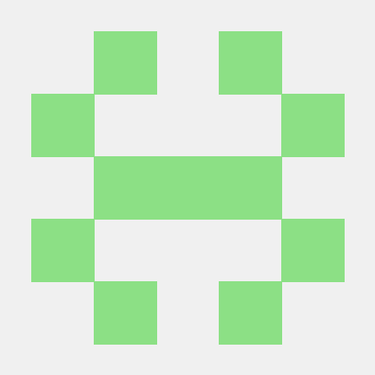

this-person

[figure not shown]

that-person

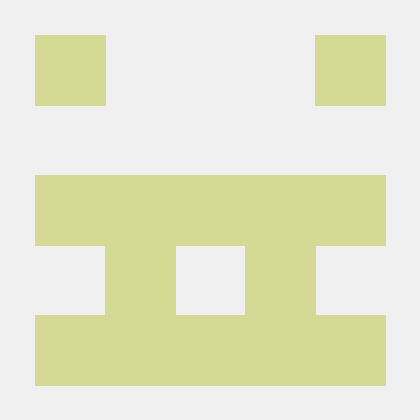

somebody

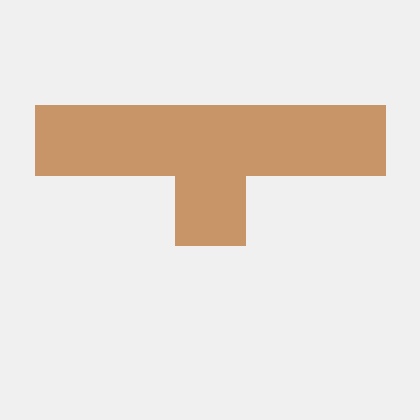

somebody-else

[figure not shown]

them

[figure not shown]

others

### Issue Authors

[figure not shown]

nobody

[figure not shown]

somebody

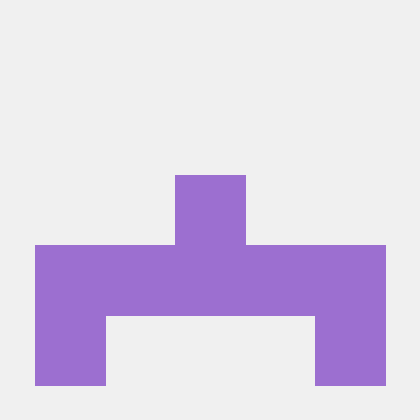

anybody

[figure not shown]

nope

[figure not shown]

yep

[figure not shown]

maybe

[figure not shown]

doubtful

### Issue Contributors

[figure not shown]

here

[figure not shown]

there

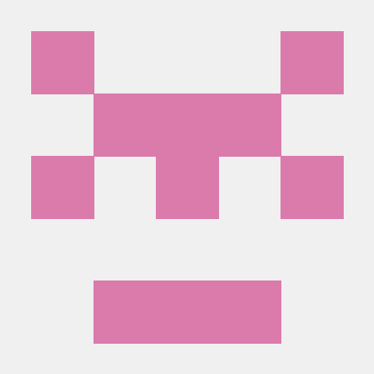

anywhere

[figure not shown]

somewhere

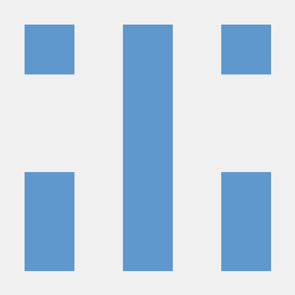

nowhere

[figure not shown]

sometime

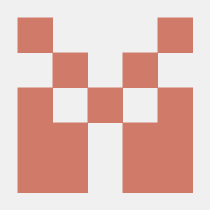

later

## Section Organisation

The default output shown above has three sections of “Code”, “Issue Authors” and “Issue Contributors”. The organisation of these sections can be controlled by the parameters `num_sections`, `type`, and `section_names`.

The `type` parameter enables sections to be removed by reducing them from the default three referred to as `code`, `issues` (for those who open issues), and `discussion` (for those who contribute to issues). For example, passing `type = "code"` will only acknowledge direct contributions to code, while ignoring all those who contributed to issues only.

The `num_sections` argument is provided for convenience, primarily in order to allow default formats to have either one, two, or three sections. Specifying `num_sections = 2` will by default collapse the “Issue Authors” and “Issue Contributors” sections into a single section named “Issues”. (This section title may be renamed with the `section_names` parameter.)

## List Format

The `format` parameter of the [`add_contributors()` function](https://docs.ropensci.org/allcontributors/reference/add_contributors.html) accepts the three options of “grid”, “list”, or “text.” With the three default section titles as shown above, the “list” option gives output that looks like this:

### Code

1. mpadge
2. this-person
3. that-person
4. somebody
5. somebody-else
6. them
7. others

### Issue Authors

1. nobody
2. somebody
3. anybody
4. nope
5. yep
6. maybe
7. doubtful

### Issue Contributors

1. here
2. there
3. anywhere
4. somewhere
5. nowhere
6. sometime
7. later

## Text Format

Finally, the text format enables contributors to be acknowledged as a single lines of text.

### Code

mpadge, this-person, that-person, somebody, somebody-else, them, others

### Issue Authors

nobody, somebody, anybody, nope, yep, maybe, doubtful

### Issue Contributors

here, there, anywhere, somewhere, nowhere, sometime, later

The shortest possible way of acknowledging your contributors would be like this:

```r
add_contributors (num_sectons = 1, format = "text")
```

which would in this case convert the above into the single list of,

mpadge, this-person, that-person, somebody, somebody-else, them, others, nobody, somebody, anybody, nope, yep, maybe, doubtful, here, there, anywhere, somewhere, nowhere, sometime, later